# Superstore Sell Data Analysis Brainwave Matrix Solution

📊 **Superstore Sales Data Analysis**  
🚀 Data Cleaning and EDA using Python (Jupyter Notebook)  
**📁 Internship Task for **Brainwave Matrix Solution****

📒 **Importing all necessary libraries**

```python
import numpy as np
import pandas as pd
import matplotlib.pyplot as plt
import seaborn as sns
%matplotlib inline
```

📒 **Importing Dataset in CSV format**

```python
df = pd.read_csv("Sample_Superstore.csv", encoding='latin1')
```

📒 **what is the shape of Data?**

```python
df.shape
```

```
(9994, 21)
```

📒 **Which columns are there?**

```python
df.columns
```

```
Index(['Row ID', 'Order ID', 'Order Date', 'Ship Date', 'Ship Mode',
       'Customer ID', 'Customer Name', 'Segment', 'Country', 'City', 'State',
       'Postal Code', 'Region', 'Product ID', 'Category', 'Sub-Category',
       'Product Name', 'Sales', 'Quantity', 'Discount', 'Profit'],
      dtype='object')
```

📒 **Let's take a first look at the dataset**

```python
df.head(5)
```

|  | Row ID | Order ID | Order Date | Ship Date | Ship Mode | Customer ID | Customer Name | Segment | Country | City | ... | Postal Code | Region | Product ID | Category | Sub-Category | Product Name | Sales | Quantity | Discount | Profit |
| --- | --- | --- | --- | --- | --- | --- | --- | --- | --- | --- | --- | --- | --- | --- | --- | --- | --- | --- | --- | --- | --- |
| 0 | 1 | CA-2016-152156 | 11/8/2016 | 11/11/2016 | Second Class | CG-12520 | Claire Gute | Consumer | United States | Henderson | ... | 42420 | South | FUR-BO-10001798 | Furniture | Bookcases | Bush Somerset Collection Bookcase | 261.9600 | 2 | 0.00 | 41.9136 |
| 1 | 2 | CA-2016-152156 | 11/8/2016 | 11/11/2016 | Second Class | CG-12520 | Claire Gute | Consumer | United States | Henderson | ... | 42420 | South | FUR-CH-10000454 | Furniture | Chairs | Hon Deluxe Fabric Upholstered Stacking Chairs,... | 731.9400 | 3 | 0.00 | 219.5820 |
| 2 | 3 | CA-2016-138688 | 6/12/2016 | 6/16/2016 | Second Class | DV-13045 | Darrin Van Huff | Corporate | United States | Los Angeles | ... | 90036 | West | OFF-LA-10000240 | Office Supplies | Labels | Self-Adhesive Address Labels for Typewriters b... | 14.6200 | 2 | 0.00 | 6.8714 |
| 3 | 4 | US-2015-108966 | 10/11/2015 | 10/18/2015 | Standard Class | SO-20335 | Sean O'Donnell | Consumer | United States | Fort Lauderdale | ... | 33311 | South | FUR-TA-10000577 | Furniture | Tables | Bretford CR4500 Series Slim Rectangular Table | 957.5775 | 5 | 0.45 | -383.0310 |
| 4 | 5 | US-2015-108966 | 10/11/2015 | 10/18/2015 | Standard Class | SO-20335 | Sean O'Donnell | Consumer | United States | Fort Lauderdale | ... | 33311 | South | OFF-ST-10000760 | Office Supplies | Storage | Eldon Fold 'N Roll Cart System | 22.3680 | 2 | 0.20 | 2.5164 |

5 rows × 21 columns

📒 **let's look for datatype of columns**

```python
df.info()
```

```
<class 'pandas.core.frame.DataFrame'>
RangeIndex: 9994 entries, 0 to 9993
Data columns (total 21 columns):
 #   Column         Non-Null Count  Dtype
---  ------         --------------  -----
 0   Row ID         9994 non-null   int64
 1   Order ID       9994 non-null   object
 2   Order Date     9994 non-null   object
 3   Ship Date      9994 non-null   object
 4   Ship Mode      9994 non-null   object
 5   Customer ID    9994 non-null   object
 6   Customer Name  9994 non-null   object
 7   Segment        9994 non-null   object
 8   Country        9994 non-null   object
 9   City           9994 non-null   object
 10  State          9994 non-null   object
 11  Postal Code    9994 non-null   int64
 12  Region         9994 non-null   object
 13  Product ID     9994 non-null   object
 14  Category       9994 non-null   object
 15  Sub-Category   9994 non-null   object
 16  Product Name   9994 non-null   object
 17  Sales          9994 non-null   float64
 18  Quantity       9994 non-null   int64
 19  Discount       9994 non-null   float64
 20  Profit         9994 non-null   float64
dtypes: float64(3), int64(3), object(15)
memory usage: 1.6+ MB
```

📒 **Is there any null values in dataset?**

```python
df.isnull().sum()
```

```
Row ID           0
Order ID         0
Order Date       0
Ship Date        0
Ship Mode        0
Customer ID      0
Customer Name    0
Segment          0
Country          0
City             0
State            0
Postal Code      0
Region           0
Product ID       0
Category         0
Sub-Category     0
Product Name     0
Sales            0
Quantity         0
Discount         0
Profit           0
dtype: int64
```

📒 **How many unique values per each column ?**

```python
df.nunique()
```

```
Row ID           9994
Order ID         5009
Order Date       1237
Ship Date        1334
Ship Mode           4
Customer ID       793
Customer Name     793
Segment             3
Country             1
City              531
State              49
Postal Code       631
Region              4
Product ID       1862
Category            3
Sub-Category       17
Product Name     1850
Sales            5825
Quantity           14
Discount           12
Profit           7287
dtype: int64
```

📒 **Let's Remove duplicates before any analysis**

```python
df = df.drop_duplicates()
```

📒 **Let's understand basic stats about our data**

```python
df.describe()
```

|  | Row ID | Postal Code | Sales | Quantity | Discount | Profit |
| --- | --- | --- | --- | --- | --- | --- |
| count | 9994.000000 | 9994.000000 | 9994.000000 | 9994.000000 | 9994.000000 | 9994.000000 |
| mean | 4997.500000 | 55190.379428 | 229.858001 | 3.789574 | 0.156203 | 28.656896 |
| std | 2885.163629 | 32063.693350 | 623.245101 | 2.225110 | 0.206452 | 234.260108 |
| min | 1.000000 | 1040.000000 | 0.444000 | 1.000000 | 0.000000 | -6599.978000 |
| 25% | 2499.250000 | 23223.000000 | 17.280000 | 2.000000 | 0.000000 | 1.728750 |
| 50% | 4997.500000 | 56430.500000 | 54.490000 | 3.000000 | 0.200000 | 8.666500 |
| 75% | 7495.750000 | 90008.000000 | 209.940000 | 5.000000 | 0.200000 | 29.364000 |
| max | 9994.000000 | 99301.000000 | 22638.480000 | 14.000000 | 0.800000 | 8399.976000 |

📊 **Business Overview & Key KPIs**

### 💰 What is the total sales?

```python
print(f"Total Sales: {df['Sales'].sum():.2f}")
```

```
Total Sales: 2297200.86
```

### 💰 What is the total profit?

```python
print(f"Total Profit: {df['Profit'].sum():.2f}")
```

```
Total Profit: 286397.02
```

### 💰 What is the total margin?

```python
profit_margin = (df['Profit'].sum() / df['Sales'].sum()) * 100
print(f"Overall Profit Margin: {profit_margin:.2f}%")
```

```
Overall Profit Margin: 12.47%
```

### 💰 What is the total quantity sold?

```python
print(f"Total Quantity: {df['Quantity'].sum():.2f}")
```

```
Total Quantity: 37873.00
```

### 💰 What is average discount?

```python
avg_discount = round(df['Discount'].mean(), 2)
print(f"Average Discount: {avg_discount * 100}%")
```

```
Average Discount: 16.0%
```

**💡 Insight:** The business has generated a Big revenue, but the overall profit margin appears modest. High total quantity sold with relatively lower profit suggests heavy discount or low-margin products.

📊 **Category And Sub-Category Wise Analysis**

**📈 Sales, Profit, and Avg Discount by Category**

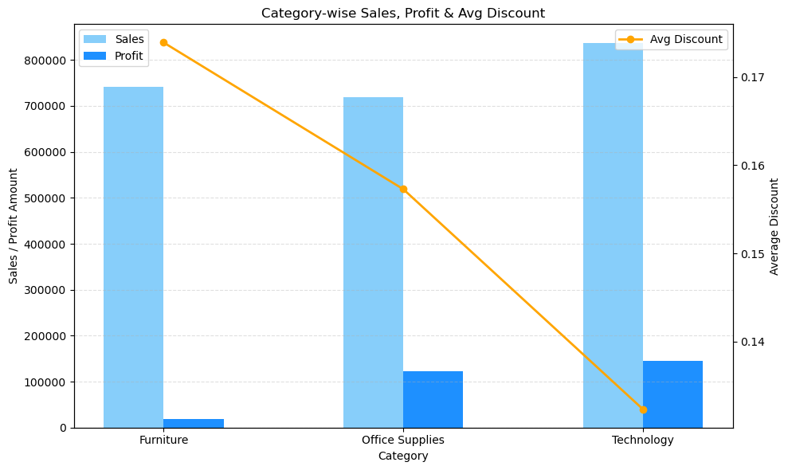

```python
# Group by Category and calculate Sales, Profit, and Avg Discount
category_data = df.groupby('Category')[['Sales', 'Profit', 'Discount']].agg({
    'Sales': 'sum',
    'Profit': 'sum',
    'Discount': 'mean'
}).reset_index()

# Bar settings
bar_width = 0.25
x = np.arange(len(category_data['Category']))

# Plotting
fig, ax1 = plt.subplots(figsize=(10, 6))

# Sales and Profit Bars
ax1.bar(x, category_data['Sales'], width=bar_width, label='Sales', color='#87CEFA')
ax1.bar(x + bar_width, category_data['Profit'], width=bar_width, label='Profit', color='#1E90FF')
ax1.set_xlabel('Category')
ax1.set_ylabel('Sales / Profit Amount')
ax1.set_xticks(x + bar_width / 2)
ax1.set_xticklabels(category_data['Category'])
ax1.legend(loc='upper left')
ax1.grid(axis='y', linestyle='--', alpha=0.4)

# Discount Line on Secondary Y-axis
ax2 = ax1.twinx()
ax2.plot(x + bar_width / 2, category_data['Discount'], color='orange', marker='o', linewidth=2, label='Avg Discount')
ax2.set_ylabel('Average Discount')
ax2.legend(loc='upper right')

plt.title('Category-wise Sales, Profit & Avg Discount')
plt.tight_layout()
plt.show()
```

**💡 Insight:** Technology leads in both sales and profit, indicating a strong market presence and margin even though with least discount. While Furniture has High Sales Still it lags in profit due to high discounts and operational costs.

**📈 Sales, Profit, and Average Discount by Sub-Category**

```python
df['Sub-Category'].nunique()
```

```
17
```

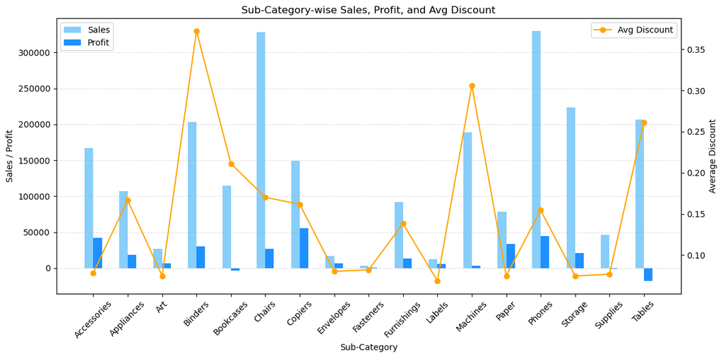

```python
# Group by Sub-Category and calculate Sales, Profit, and Avg Discount
category_data = df.groupby('Sub-Category')[['Sales', 'Profit', 'Discount']].agg({
    'Sales': 'sum',
    'Profit': 'sum',
    'Discount': 'mean'
}).reset_index()

bar_width = 0.25
x = np.arange(len(category_data['Sub-Category']))

# Plotting
fig, ax1 = plt.subplots(figsize=(12, 6))

# Sales and Profit Bar
ax1.bar(x, category_data['Sales'], width=bar_width, label='Sales', color='#87CEFA')
ax1.bar(x + bar_width, category_data['Profit'], width=bar_width, label='Profit', color='#1E90FF')
ax1.set_xlabel('Sub-Category')
ax1.set_ylabel('Sales / Profit')
ax1.set_xticks(x + bar_width / 2)
ax1.set_xticklabels(category_data['Sub-Category'], rotation=45)
ax1.legend(loc='upper left')
ax1.grid(axis='y', linestyle='--', alpha=0.4)

# Discount Line on Secondary Y-axis
ax2 = ax1.twinx()
ax2.plot(x + bar_width / 2, category_data['Discount'], color='orange', marker='o', label='Avg Discount')
ax2.set_ylabel('Average Discount')
ax2.legend(loc='upper right')

plt.title('Sub-Category-wise Sales, Profit, and Avg Discount')
plt.tight_layout()
plt.show()
```

**💡 Insight:** Chairs and Phones dominate sub-category sales, while Copiers have the highest profit. Some items like Tables and Bookcases have descent sales but suffer in profit, Decrease in binders and machines's Discount can increase their profit

**📈 Top 5 Products by Sales and Profit**

```python
from IPython.display import display, HTML

# Top 5 Products by Sales
top_sales_table = (
    df.groupby("Product Name")["Sales"]
    .sum()
    .sort_values(ascending=False)
    .head(5)
    .reset_index()
)
top_sales_table.columns = ["Product Name", "Total Sales"]
top_sales_table["Sales Rank"] = range(1, 6)

# Top 5 Products by Profit
top_profit_table = (
    df.groupby("Product Name")["Profit"]
    .sum()
    .sort_values(ascending=False)
    .head(5)
    .reset_index()
)
top_profit_table.columns = ["Product Name", "Total Profit"]
top_profit_table["Profit Rank"] = range(1, 6)

# Convert tables to HTML and display side by side
sales_html = top_sales_table.to_html(index=False)
profit_html = top_profit_table.to_html(index=False)

display(HTML(f"""
<style>
    th {{
        text-align: center !important;
    }}
    td {{
        text-align: center;
    }}
</style>
<div style="display: flex; justify-content: space-between;">
    <div style="margin-right: 20px;">{sales_html}</div>
    <div>{profit_html}</div>
</div>
"""))
```

| Product Name | Total Sales | Sales Rank |
| --- | --- | --- |
| Canon imageCLASS 2200 Advanced Copier | 61599.824 | 1 |
| Fellowes PB500 Electric Punch Plastic Comb Binding Machine with Manual Bind | 27453.384 | 2 |
| Cisco TelePresence System EX90 Videoconferencing Unit | 22638.480 | 3 |
| HON 5400 Series Task Chairs for Big and Tall | 21870.576 | 4 |
| GBC DocuBind TL300 Electric Binding System | 19823.479 | 5 |

| Product Name | Total Profit | Profit Rank |
| --- | --- | --- |
| Canon imageCLASS 2200 Advanced Copier | 25199.9280 | 1 |
| Fellowes PB500 Electric Punch Plastic Comb Binding Machine with Manual Bind | 7753.0390 | 2 |
| Hewlett Packard LaserJet 3310 Copier | 6983.8836 | 3 |
| Canon PC1060 Personal Laser Copier | 4570.9347 | 4 |
| HP Designjet T520 Inkjet Large Format Printer - 24" Color | 4094.9766 | 5 |

**💡 Insight:**The product **Canon imageCLASS 2200 Advanced Copier** tops both in sales and profit, clearly indicating its strong commercial performance. However, some products like **Hewlett Packard LaserJet 3310 Copier** and **Canon PC1060 Personal Laser Copier** appeared in the top 5 by profit but not by sales — highlighting their higher margins despite lower sales volume. Such insights help in identifying high-margin items that may deserve more promotion or stocking priority.

**📈 Average Discount by Category**

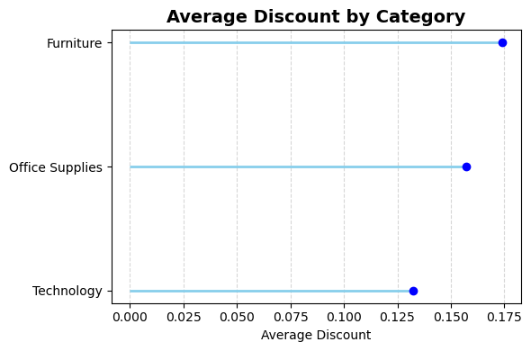

```python
# Grouping the data
category_discount = df.groupby('Category')['Discount'].mean().sort_values()

# Plotting
plt.figure(figsize=(6, 4))
plt.hlines(y=category_discount.index, xmin=0, xmax=category_discount.values, color='skyblue', linewidth=2)
plt.plot(category_discount.values, category_discount.index, "o", color='blue')

# Titles and labels
plt.title('Average Discount by Category', fontsize=14, fontweight='bold')
plt.xlabel('Average Discount')
plt.grid(axis='x', linestyle='--', alpha=0.5)
plt.tight_layout()
plt.show()
```

**💡 Insight:** Furniture receives the highest average discount, which may explain its lower profitability despite good sales.

**📈 Average Discount by Sub-Category**

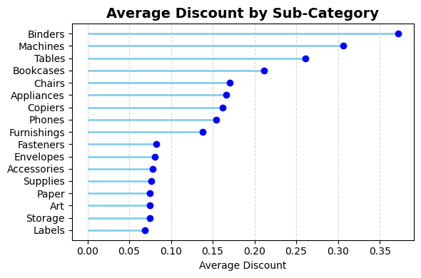

```python
# Grouping the data
category_discount = df.groupby('Sub-Category')['Discount'].mean().sort_values()

# Plotting
plt.figure(figsize=(6, 4))
plt.hlines(y=category_discount.index, xmin=0, xmax=category_discount.values, color='skyblue', linewidth=2)
plt.plot(category_discount.values, category_discount.index, "o", color='blue')

# Titles and labels
plt.title('Average Discount by Sub-Category', fontsize=14, fontweight='bold')
plt.xlabel('Average Discount')
plt.grid(axis='x', linestyle='--', alpha=0.5)
plt.tight_layout()
plt.show()
```

**📈 Category wise Shipment Mode Distribution**

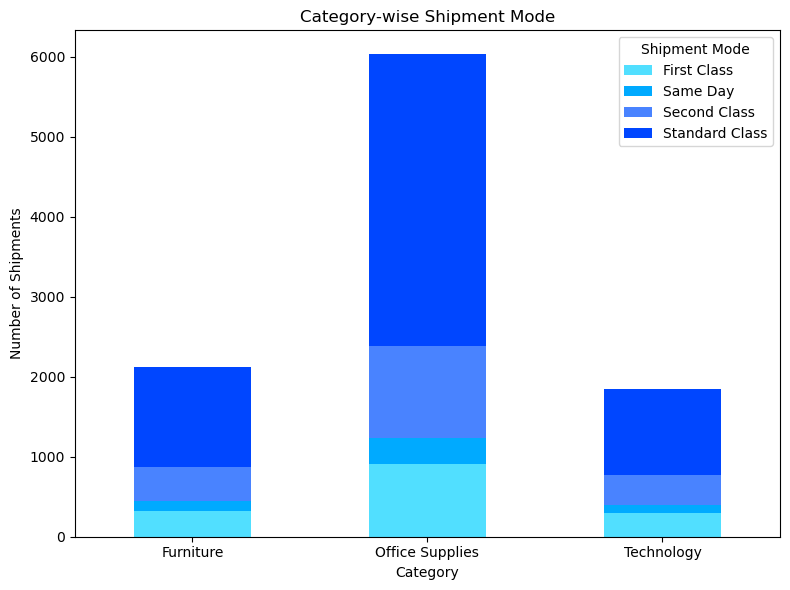

```python
# Group by Category and Shipment
shipment_data = df.groupby(['Category', 'Ship Mode']).size().unstack(fill_value=0)
blue_shades = ['#51dfff','#00aaff','#4983ff','#0046ff']
# Plotting stacked bar chart with blue shades
shipment_data.plot(kind='bar', stacked=True, figsize=(8, 6), color=blue_shades)

# Labels and Title
plt.title('Category-wise Shipment Mode')
plt.xlabel('Category')
plt.ylabel('Number of Shipments')
plt.xticks(rotation=0)
plt.legend(title='Shipment Mode')
plt.tight_layout()
plt.show()
```

**💡 Insight:** Standard Class is the preferred shipping mode across all categories. However, Technology has a larger share of Second Class and First Class shipments, possibly reflecting urgency and customer expectation.

**📈 Category-wise Segment Distribution**

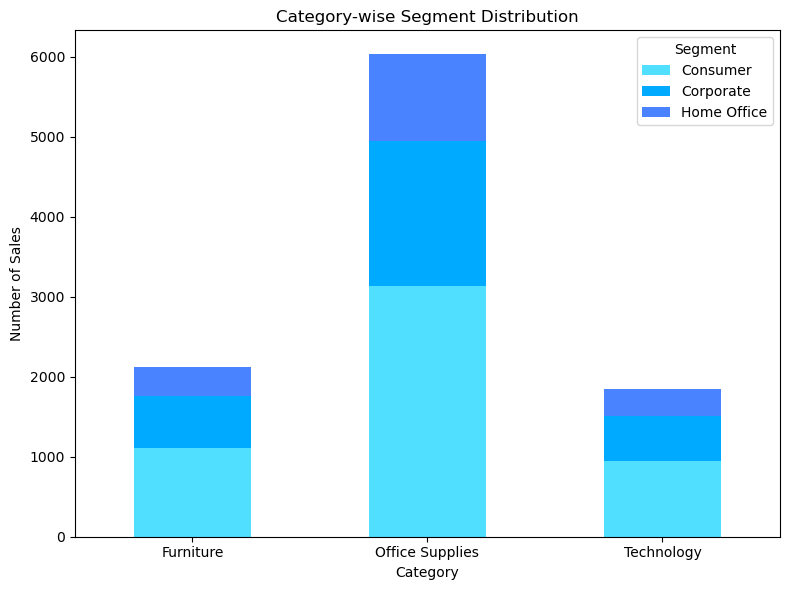

```python
# Group by Category and Segment (assuming 'Segment' is a column)
segment_data = df.groupby(['Category', 'Segment']).size().unstack(fill_value=0)

# Define custom color palette for segment chart
custom_colors_segment = ['#51dfff', '#00aaff', '#4983ff', '#0046ff']

# Plotting stacked bar chart for Segment-wise data
segment_data.plot(kind='bar', stacked=True, figsize=(8, 6), color=custom_colors_segment)

# Labels and Title
plt.title('Category-wise Segment Distribution')
plt.xlabel('Category')
plt.ylabel('Number of Sales')
plt.xticks(rotation=0)
plt.legend(title='Segment')
plt.tight_layout()
plt.show()
```

**💡 Insight:** Consumer segment is the major contributor across all categories, but the Corporate segment in Office Supplies category also drives notable sales.

**📈 Order Quantity Distribution By Category and Sub-Category**

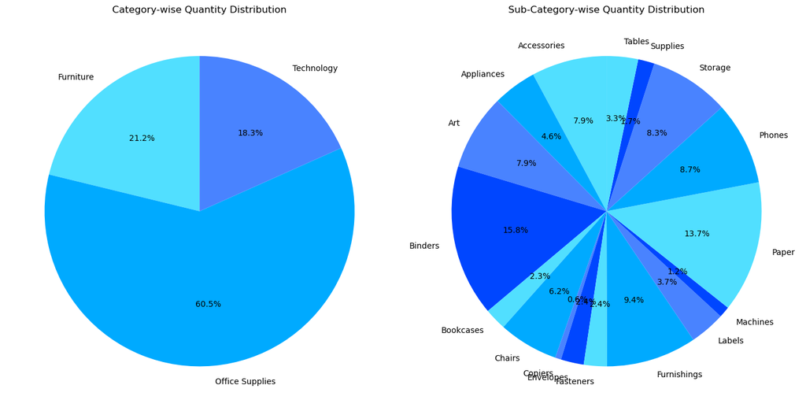

```python
# Group by Category and calculate the sum of Quantity
category_quantity = df.groupby('Category')['Quantity'].sum()

# Group by Sub-Category and calculate the sum of Quantity
sub_category_quantity = df.groupby('Sub-Category')['Quantity'].sum()

# Define the custom colors
category_colors = ['#51dfff', '#00aaff', '#4983ff', '#0046ff'] * (len(category_quantity) // 4 + 1)  # Repeat to match number of categories
sub_category_colors = ['#51dfff', '#00aaff', '#4983ff', '#0046ff'] * (len(sub_category_quantity) // 4 + 1)  # Repeat to match number of sub-categories

# Plotting both pie charts side by side
fig, axes = plt.subplots(1, 2, figsize=(14, 7))

# Category-wise pie chart
axes[0].pie(category_quantity, labels=category_quantity.index, autopct='%1.1f%%', startangle=90, colors=category_colors[:len(category_quantity)])
axes[0].set_title('Category-wise Quantity Distribution')

# Sub-Category-wise pie chart
axes[1].pie(sub_category_quantity, labels=sub_category_quantity.index, autopct='%1.1f%%', startangle=90, colors=sub_category_colors[:len(sub_category_quantity)])
axes[1].set_title('Sub-Category-wise Quantity Distribution')

# Show the pie charts
plt.tight_layout()
plt.show()
```

**💡 Insight:** The pie charts reveal that the **Office Supplies** category dominates total order quantity, especially driven by sub-categories like **Binders** and **Paper**. Meanwhile, categories like **Technology** and **Furniture** have relatively lower shares, suggesting their higher-value but lower-volume nature. Sub-categories such as **Tables** and **Chairs** contribute modestly, aligning with their bulky and less frequently ordered profile.

📊 **Time Series Analysis: Sales, Profit, and Quantity Trends by Category Over Time**

```python
df['Order Date'] = pd.to_datetime(df['Order Date'], errors='coerce')
df['Ship Date'] = pd.to_datetime(df['Ship Date'], errors='coerce')
```

**📅 Profit And Sales Monthly and Yearly Trend**

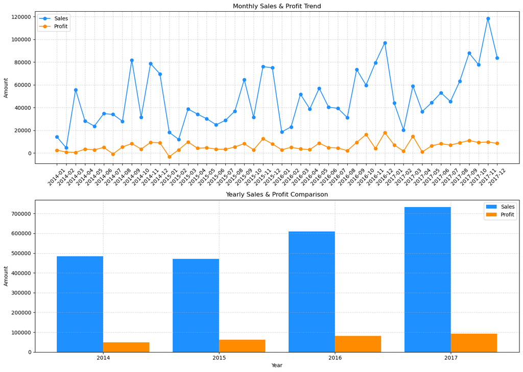

```python
import pandas as pd
import matplotlib.pyplot as plt
import numpy as np

# Ensure dates are parsed correctly
df['Order Date'] = pd.to_datetime(df['Order Date'], errors='coerce')

# Create new columns
df['Year-Month'] = df['Order Date'].dt.to_period('M').astype(str)
df['Year'] = df['Order Date'].dt.year

# Group data
monthly = df.groupby('Year-Month')[['Sales', 'Profit']].sum().reset_index()
yearly = df.groupby('Year')[['Sales', 'Profit']].sum().reset_index()

# X positions for yearly bars
x = np.arange(len(yearly['Year']))
bar_width = 0.4

# Plotting
fig, axs = plt.subplots(2, 1, figsize=(14, 10))

# --- Monthly Line Chart ---
axs[0].plot(monthly['Year-Month'], monthly['Sales'], label='Sales', color='dodgerblue', marker='o')
axs[0].plot(monthly['Year-Month'], monthly['Profit'], label='Profit', color='darkorange', marker='o')
axs[0].set_title('Monthly Sales & Profit Trend')
axs[0].set_ylabel('Amount')
axs[0].legend()
axs[0].grid(True, linestyle='--', alpha=0.5)
axs[0].tick_params(axis='x', rotation=45)

# --- Yearly Bar Chart ---
axs[1].bar(x - bar_width/2, yearly['Sales'], width=bar_width, label='Sales', color='dodgerblue')
axs[1].bar(x + bar_width/2, yearly['Profit'], width=bar_width, label='Profit', color='darkorange')
axs[1].set_title('Yearly Sales & Profit Comparison')
axs[1].set_xlabel('Year')
axs[1].set_ylabel('Amount')
axs[1].set_xticks(x)
axs[1].set_xticklabels(yearly['Year'])
axs[1].legend()
axs[1].grid(True, linestyle='--', alpha=0.5)

plt.tight_layout()
plt.show()
```

**📅 Category Wise Monthly Trend Of Profit And Sales**

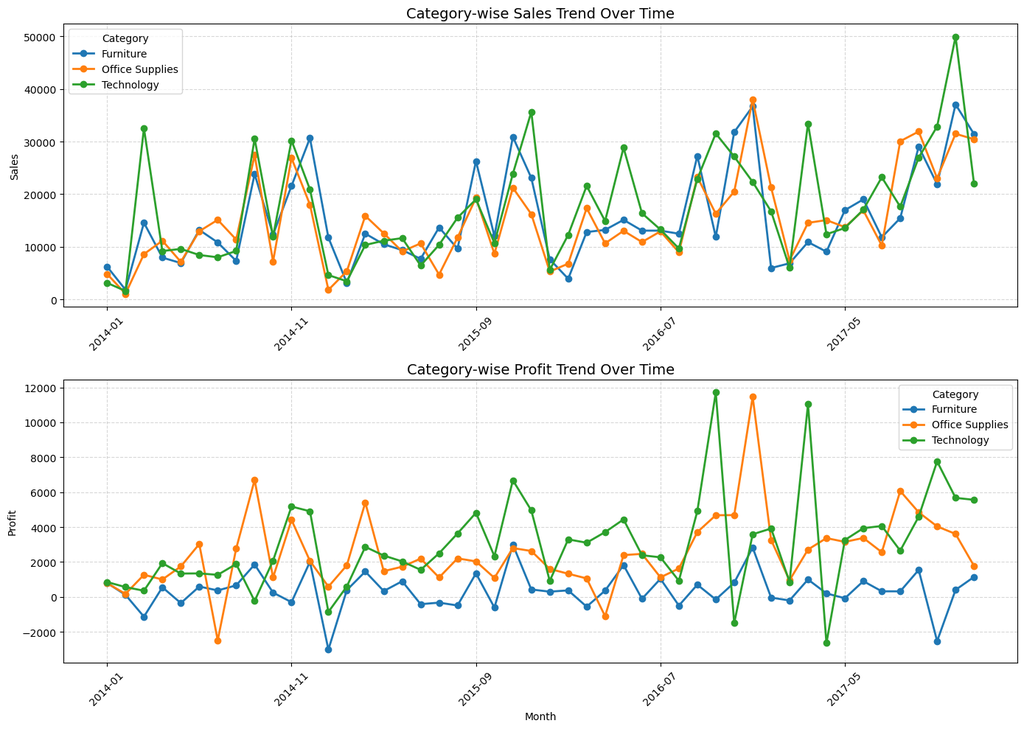

```python
# Create Year-Month column
df['Year-Month'] = df['Order Date'].dt.to_period('M').astype(str)

# Group by Year-Month and Category
cat_monthly = df.groupby(['Year-Month', 'Category'])[['Sales', 'Profit']].sum().reset_index()

# Pivot data
sales_pivot = cat_monthly.pivot(index='Year-Month', columns='Category', values='Sales')
profit_pivot = cat_monthly.pivot(index='Year-Month', columns='Category', values='Profit')

# Plot
plt.figure(figsize=(14, 10))

# Sales Chart
plt.subplot(2, 1, 1)
sales_pivot.plot(ax=plt.gca(), marker='o', linewidth=2)
plt.title('Category-wise Sales Trend Over Time', fontsize=14)
plt.xlabel('')
plt.ylabel('Sales')
plt.xticks(rotation=45)
plt.grid(True, linestyle='--', alpha=0.5)

# Profit Chart
plt.subplot(2, 1, 2)
profit_pivot.plot(ax=plt.gca(), marker='o', linewidth=2)
plt.title('Category-wise Profit Trend Over Time', fontsize=14)
plt.xlabel('Month')
plt.ylabel('Profit')
plt.xticks(rotation=45)
plt.grid(True, linestyle='--', alpha=0.5)

plt.tight_layout()
plt.show()
```

**💡 Insight:** The**Technology** category shows consistent peaks in both sales and profit across multiple months, affirming its high-margin nature. **Office Supplies** demonstrates volume-driven sales but comparatively modest profits, while **Furniture** exhibits occasional profit dips even during high sales months, signaling possible heavy-discount promotions.

**📅 Sales vs Discount Monthly Trend**

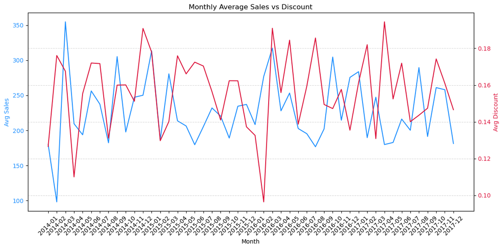

```python
monthly = df.groupby('Year-Month')[['Sales', 'Discount']].mean().reset_index()

fig, ax1 = plt.subplots(figsize=(12, 6))

# Sales line
ax1.plot(monthly['Year-Month'], monthly['Sales'], color='dodgerblue', label='Average Sales')
ax1.set_xlabel('Month')
ax1.set_ylabel('Avg Sales', color='dodgerblue')
ax1.tick_params(axis='y', labelcolor='dodgerblue')
ax1.tick_params(axis='x', rotation=45)

# Twin axis for Discount
ax2 = ax1.twinx()
ax2.plot(monthly['Year-Month'], monthly['Discount'], color='crimson', label='Average Discount')
ax2.set_ylabel('Avg Discount', color='crimson')
ax2.tick_params(axis='y', labelcolor='crimson')

# Title and layout
plt.title('Monthly Average Sales vs Discount')
fig.tight_layout()
plt.grid(True, linestyle='--', alpha=0.5)
plt.show()
```

**📅 Average of Shipping Delay Monthly**

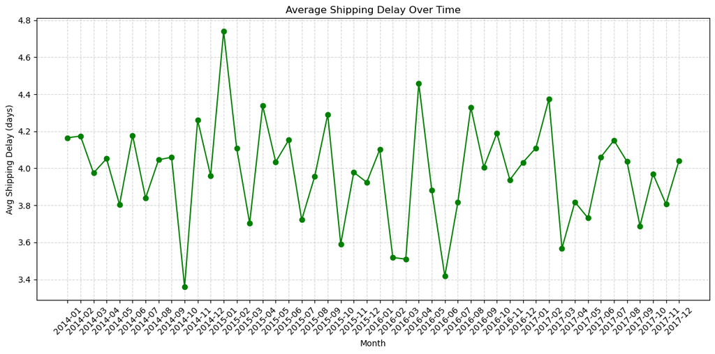

```python
df['Ship Date'] = pd.to_datetime(df['Ship Date'], errors='coerce')
df['Ship Delay'] = (df['Ship Date'] - df['Order Date']).dt.days

delay_monthly = df.groupby('Year-Month')['Ship Delay'].mean().reset_index()

plt.figure(figsize=(12, 6))
plt.plot(delay_monthly['Year-Month'], delay_monthly['Ship Delay'], color='green', marker='o')
plt.title('Average Shipping Delay Over Time')
plt.xlabel('Month')
plt.ylabel('Avg Shipping Delay (days)')
plt.xticks(rotation=45)
plt.grid(True, linestyle='--', alpha=0.5)
plt.tight_layout()
plt.show()
```

**💡 Insight:** Monthly shipping delay analysis shows that average delays hover between 3–5 days, with noticeable spikes around the end of the year. This pattern may reflect seasonal congestion, possibly due to holiday sales.

📊 **Spatial Analysis**

```python
df['City'].nunique()
```

```
531
```

🗺️ State Wise Sales & Profit Trends

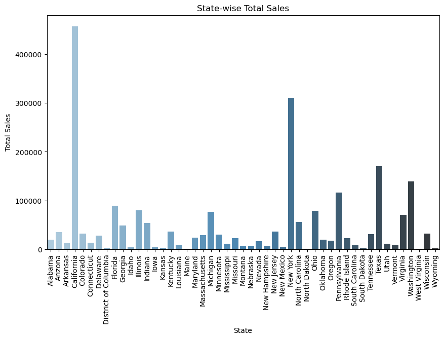

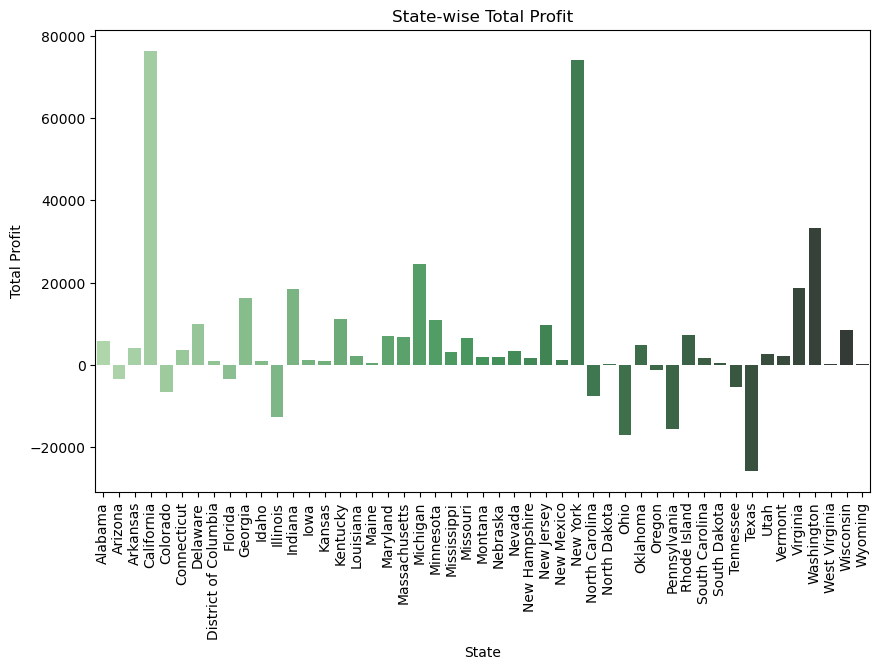

```python
import pandas as pd
import matplotlib.pyplot as plt
import seaborn as sns

# Assuming you have df with 'State', 'City', 'Sales', 'Profit' columns

# Group by state and calculate sum of sales and profit
state_sales_profit = df.groupby('State')[['Sales', 'Profit']].agg('sum').reset_index()

# Plot State-wise Sales
plt.figure(figsize=(10, 6))
sns.barplot(x='State', y='Sales', data=state_sales_profit, palette='Blues_d')
plt.xticks(rotation=90)
plt.title('State-wise Total Sales')
plt.xlabel('State')
plt.ylabel('Total Sales')
plt.show()

# Plot State-wise Profit
plt.figure(figsize=(10, 6))
sns.barplot(x='State', y='Profit', data=state_sales_profit, palette='Greens_d')
plt.xticks(rotation=90)
plt.title('State-wise Total Profit')
plt.xlabel('State')
plt.ylabel('Total Profit')
plt.show()
```

**💡 Insight:** Sales are highest in states like California and New York, confirming their economic weight. These should remain primary focus areas, but lower-performing states also show potential for growth. Not all high-sales states yield high profits. Some states with lower sales outperform others in terms of profitability, emphasizing the need for cost control and strategic pricing.

🗺️ Top 5 Cities by Profit And Sales

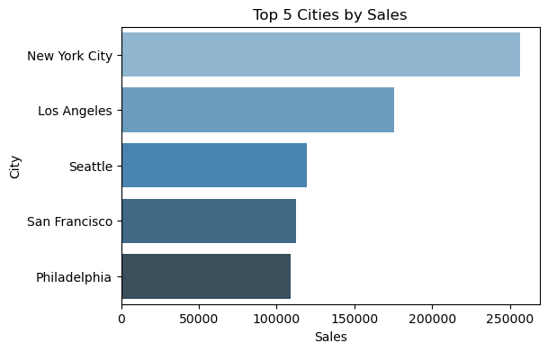

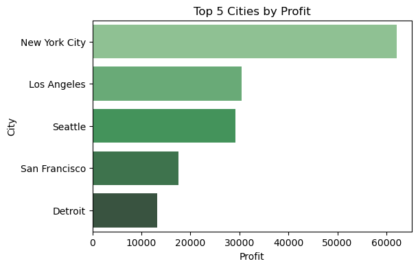

```python
# Group by city and calculate sum of sales and profit
city_sales_profit = df.groupby('City')[['Sales', 'Profit']].agg('sum').reset_index()

# Top 5 cities by Sales
top_5_sales = city_sales_profit.nlargest(5, 'Sales')

# Plot Top 5 Cities by Sales
plt.figure(figsize=(6, 4))
sns.barplot(x='Sales', y='City', data=top_5_sales, palette='Blues_d')
plt.title('Top 5 Cities by Sales')
plt.xlabel('Sales')
plt.ylabel('City')
plt.show()
# Top 5 cities by Profit
top_5_profit = city_sales_profit.nlargest(5, 'Profit')
# Plot Top 5 Cities by Profit
plt.figure(figsize=(6, 4))
sns.barplot(x='Profit', y='City', data=top_5_profit, palette='Greens_d')
plt.title('Top 5 Cities by Profit')
plt.xlabel('Profit')
plt.ylabel('City')
plt.show()
```

**💡 Insight:** Los Angeles and New York City lead in both sales and profit, reaffirming their status as prime business hubs.

🗺️ High-Risk Cities : Negative Profit

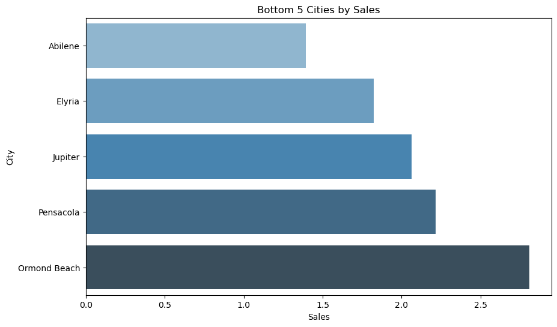

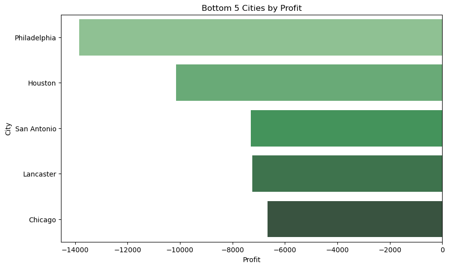

```python
# Bottom 5 cities by Sales
bottom_5_sales = city_sales_profit.nsmallest(5, 'Sales')

# Plot Bottom 5 Cities by Sales
plt.figure(figsize=(10, 6))
sns.barplot(x='Sales', y='City', data=bottom_5_sales, palette='Blues_d')
plt.title('Bottom 5 Cities by Sales')
plt.xlabel('Sales')
plt.ylabel('City')
plt.show()

# Bottom 5 cities by Profit
bottom_5_profit = city_sales_profit.nsmallest(5, 'Profit')

# Plot Bottom 5 Cities by Profit
plt.figure(figsize=(10, 6))
sns.barplot(x='Profit', y='City', data=bottom_5_profit, palette='Greens_d')
plt.title('Bottom 5 Cities by Profit')
plt.xlabel('Profit')
plt.ylabel('City')
plt.show()
```

🗺️ Profit-to-Sales Ratio by State

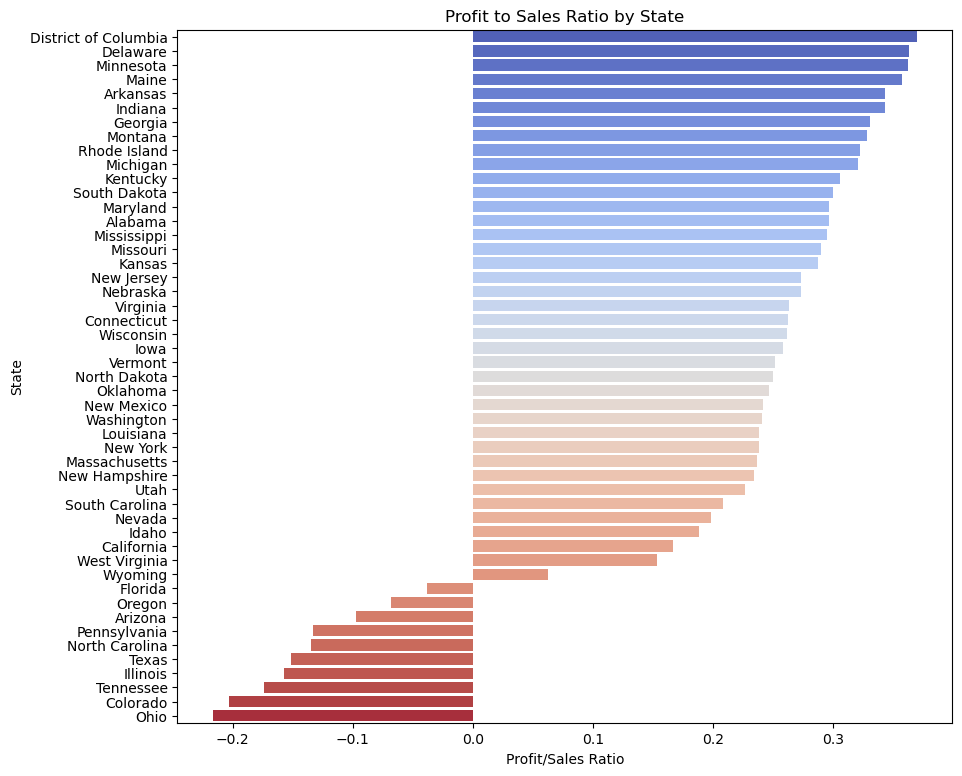

```python
state_sales_profit['Profit_Sales_Ratio'] = state_sales_profit['Profit'] / state_sales_profit['Sales']

# Sort by ratio
state_ratio_sorted = state_sales_profit.sort_values(by='Profit_Sales_Ratio', ascending=False)

# Plot
plt.figure(figsize=(10,9))
sns.barplot(data=state_ratio_sorted, x='Profit_Sales_Ratio', y='State', palette='coolwarm')
plt.title("Profit to Sales Ratio by State")
plt.xlabel("Profit/Sales Ratio")
plt.ylabel("State")
plt.show()
```

**💡 Insight:**Some States like Ohio,Texas with high sales are operating at a loss or very low margins, while others with moderate sales maintain healthier profit margins. This highlights areas for potential operational optimization.

🗺️ Region-wise Sales And Profit

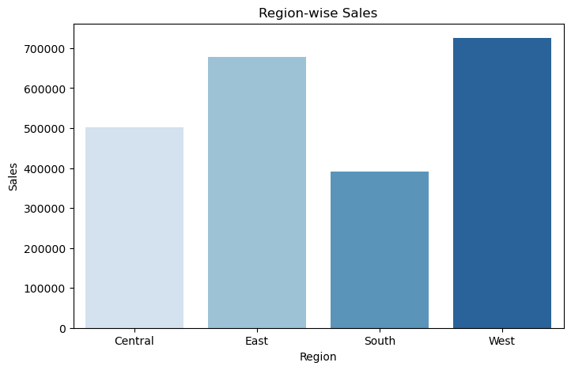

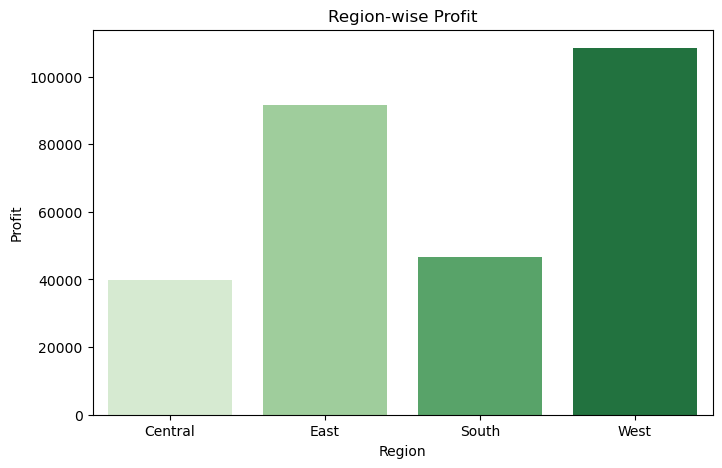

```python
region_agg = df.groupby('Region')[['Sales', 'Profit']].sum().reset_index()

# Plot
plt.figure(figsize=(8,5))
sns.barplot(data=region_agg, x='Region', y='Sales', palette='Blues')
plt.title("Region-wise Sales")
plt.show()

plt.figure(figsize=(8,5))
sns.barplot(data=region_agg, x='Region', y='Profit', palette='Greens')
plt.title("Region-wise Profit")
plt.show()
```

🗺️ Contribution % to Total Sales by Top State

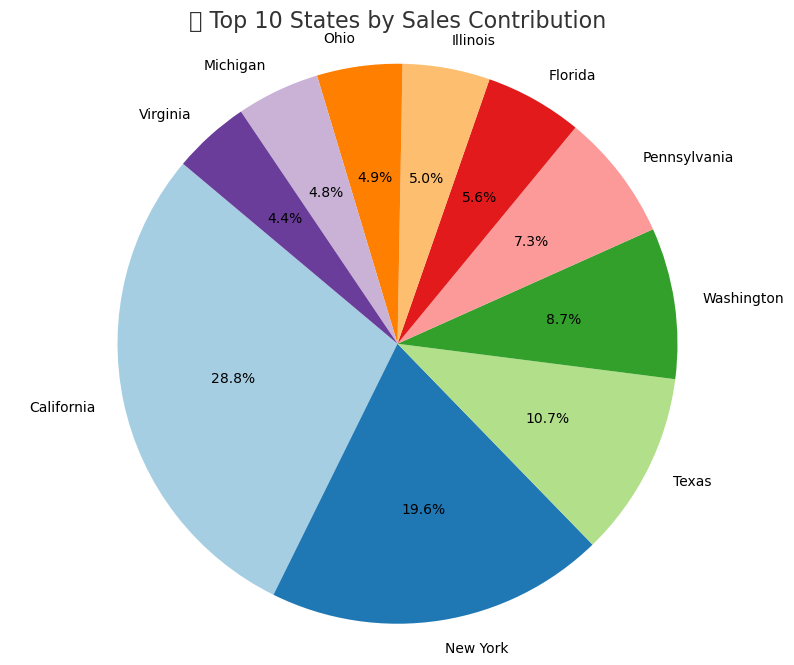

```python
# Aggregate total sales per state
state_sales = df.groupby('State')['Sales'].sum().sort_values(ascending=False).head(10)

# Plotting
plt.figure(figsize=(10, 8))
plt.pie(state_sales, labels=state_sales.index, autopct='%1.1f%%', startangle=140, colors=plt.cm.Paired.colors)
plt.title('📊 Top 10 States by Sales Contribution', fontsize=16, color='#333')
plt.axis('equal')  # Equal aspect ratio ensures that pie is drawn as a circle.
plt.show()
```

🗺️ Box Plot: Distribution of Profit Per State

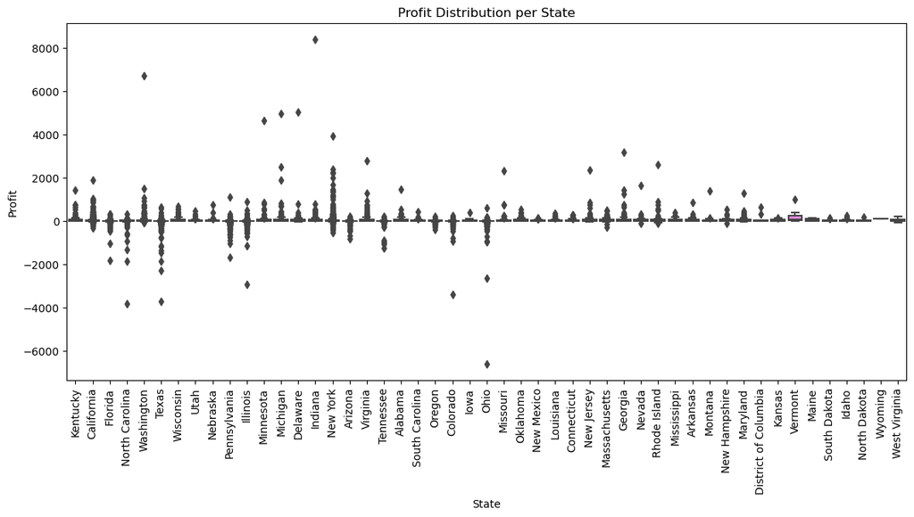

```python
plt.figure(figsize=(14,6))
sns.boxplot(data=df, x='State', y='Profit')
plt.xticks(rotation=90)
plt.title("Profit Distribution per State")
plt.show()
```

**💡 Insight:** The box plot uncovers that most states have profit values tightly clustered around the median, but there are several extreme outliers on both ends. A few states, such as **Texas** and **Illinois**, show notable negative profit instances, while states like **California** and **New York** contribute to the upper end. This distribution highlights significant variability in profitability across states that can't be captured by averages alone.

### 📌 Final Takeaways & Strategic Suggestions

**📈 Suggestion:** Focus on high-performing product lines with balanced discounting. Minimize loss-making sub-categories or improve cost efficiency in their delivery. Prioritize targeted strategies based on state-wise and segment-level performance.

**🙏 Thank You**  
I would like to sincerely thank **Brainwave Matrix Solution** for giving me the opportunity to work on this project as part of the virtual internship. This task not only helped me apply my Python and data analysis skills, but also deepened my understanding of business metrics, visual storytelling, and strategic insight generation.  
I look forward to contributing more in upcoming tasks and continuing to grow as a data enthusiast and problem solver. ✨